# Crime Risk Prediction in Chicago

Yuewen Dai

2022-10-20

## Introduction

Crime has always been a key factor in cities that has a great impact on land values, zoning, resource allocation, etc. Analyzing crime-related factors and making predictions on crimes can help policymakers decide on regional policies, help police deploy resources more rationally, and also help people visualize the safety of a region more directly. This time, I build a model by borrowing experiences from places where crime has been observed and test whether these experiences can generalize to places that may be a risk for crime.

The results of the test showed that in Chicago, the crime location data predicted by the previous year’s (2018) experience for the following year (2019) matched well with the actual occurrence, validating that my model is worth being replicated.

## Analysis

### 1.Map of Weapons Violation

Here, I show a map of crimes related to weapons violation that occurred in Chicago in 2018. As you can see, there are very clear clusters near the northwest and southwest areas.

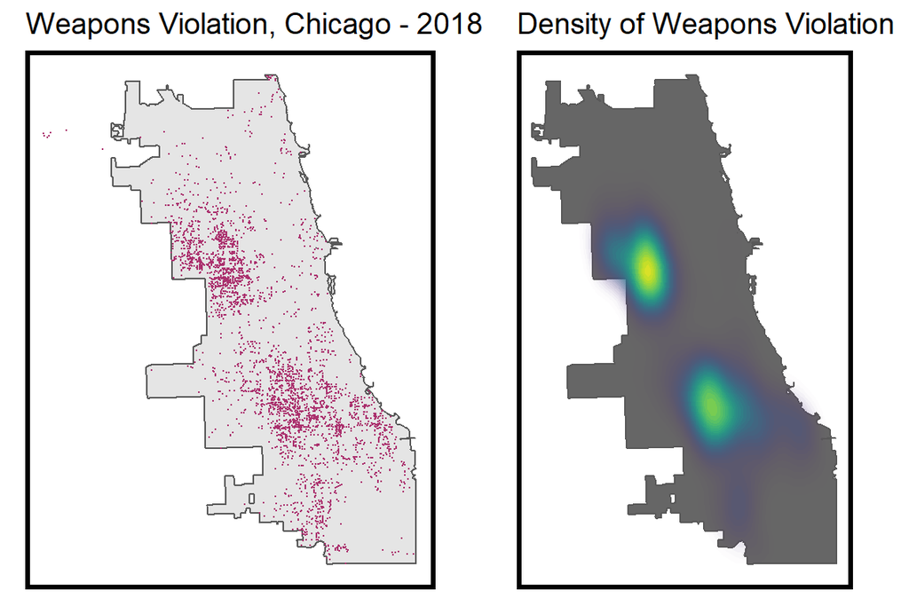

### 2.Map of Weapons Violation in fishnet

Considering crime risk not as a phenomenon that varies across administrative units, but one varying smoothly across landscape, it’s more suitable to build grid cells to show these crime “hotspots”.

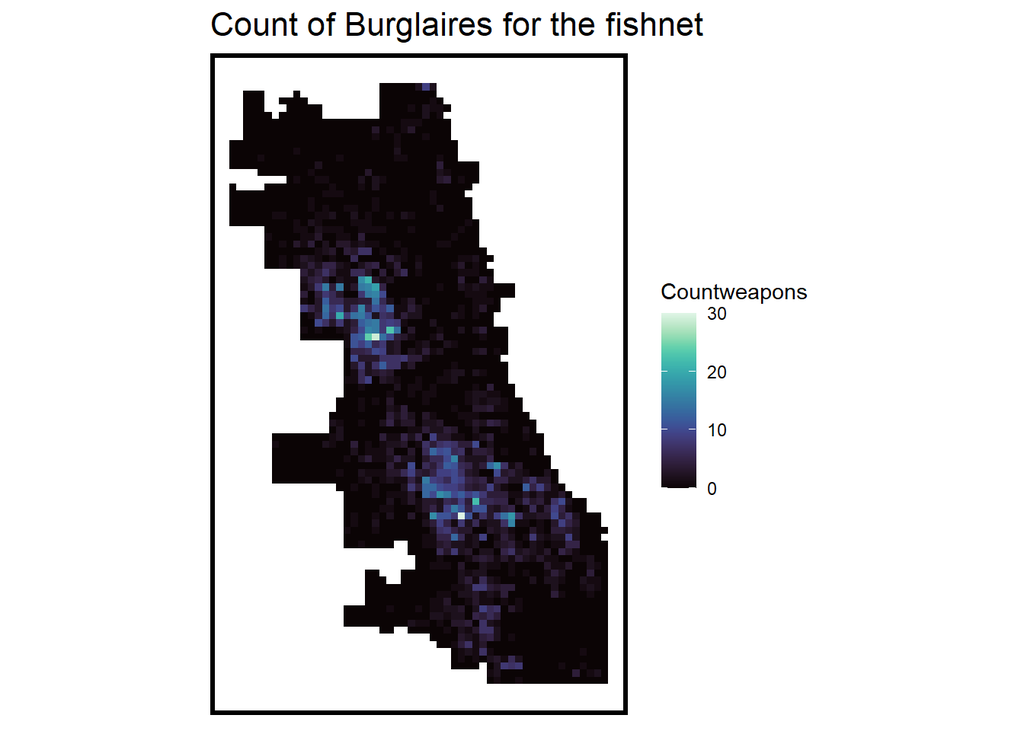

### 3.Risk factors in fishnet

Here, I collected and introduced some independent factors that I thought would be strongly associated with crime and presented them in the previously established spatial grid.

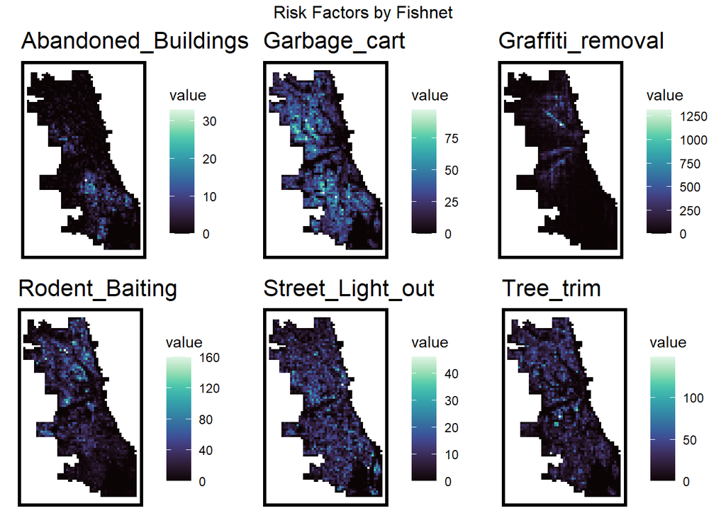

Also, I calculated their average distance from the three closest crimes and created new distance variables that are presented in the map.

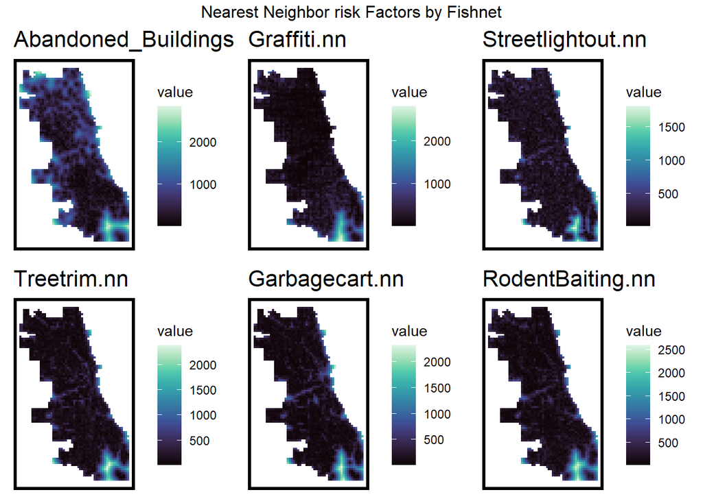

### 4.Local Moran’s I map

From the map, we can see that Local Moran’s I has higher values in regions where more crimes occur, indicating that regional crime spatial autocorrelation is relatively high.

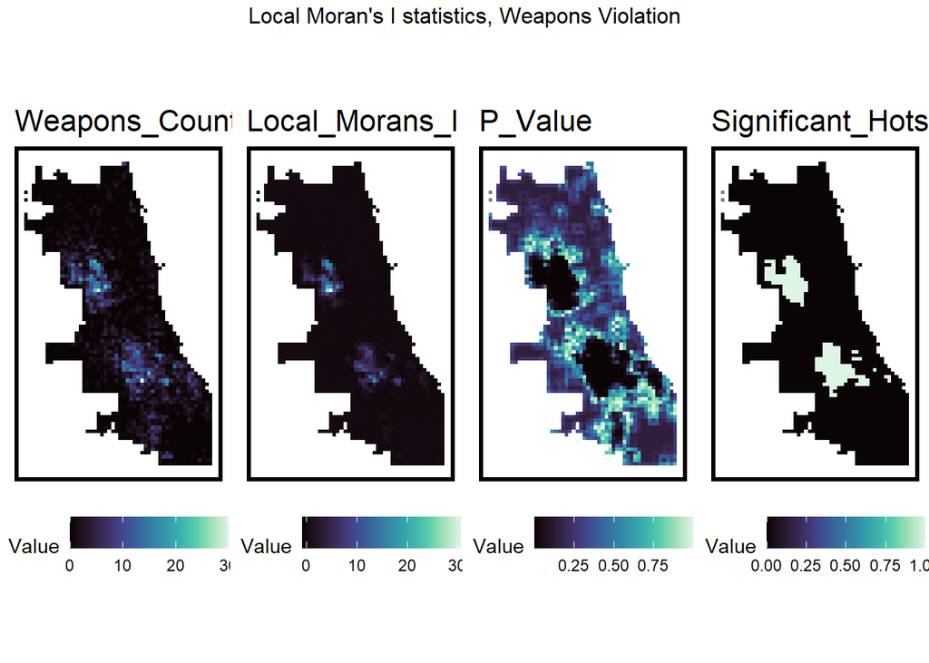

### 5.Small multiple scatter plots with correlations

Here, we can test the correlation between our selected variables and the crime. It can be seen that the highest correlation is for vacant houses.

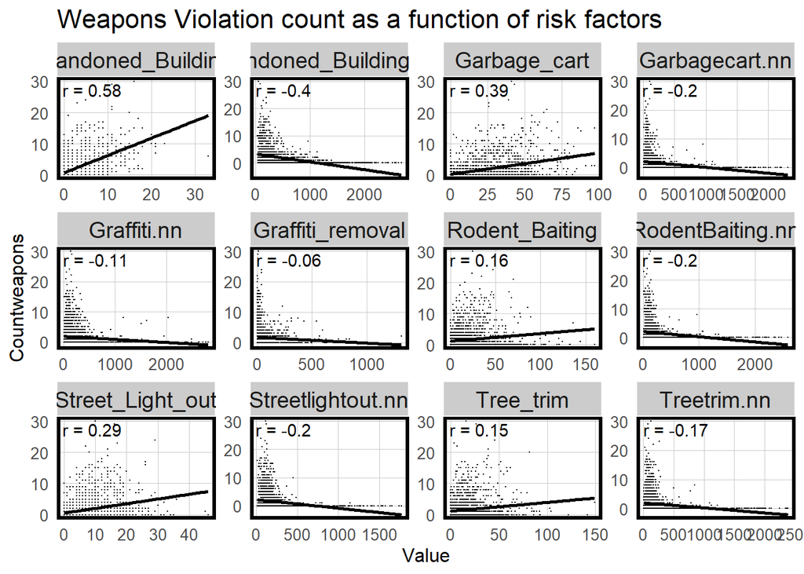

### 6.A histogram of dependent variable

Here I counted the value of how many of crimes occurred in each cell.

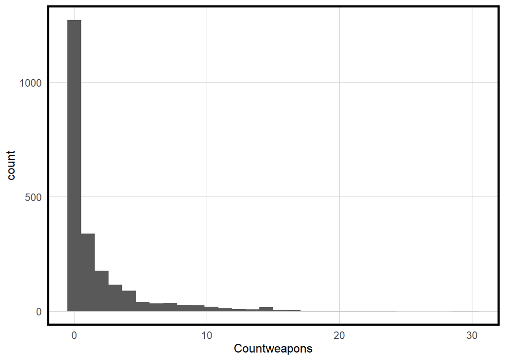

### 7.A table of MAE and standard deviation MAE by regression

Here, I conducted spatial cross-validation to test and improve model’s prediction spatial accuracy .

[output not shown]

[output cut: 41 more lines]

[output not shown]

I calculated the mean and standard deviation in errors by regression. The results confirms our conclusion that the spatial process features improve the model.

| Regression | Mean_MAE | SD_MAE |
| --- | --- | --- |
| Random k-foldCV:JustRiskFactors | 0.46 | 0.36 |
| Random k-foldCV:SpatialProcess | 0.41 | 0.36 |
| Spatial LOGO-CV:JustRiskFactors | 0.81 | 0.84 |
| Spatial LOGO-CV:SpatialProcess | 0.52 | 0.52 |

### 8.A small multiple map of model errors by random k-fold and spatial cross validation

The map shows the largest errors are in the hotspot location.

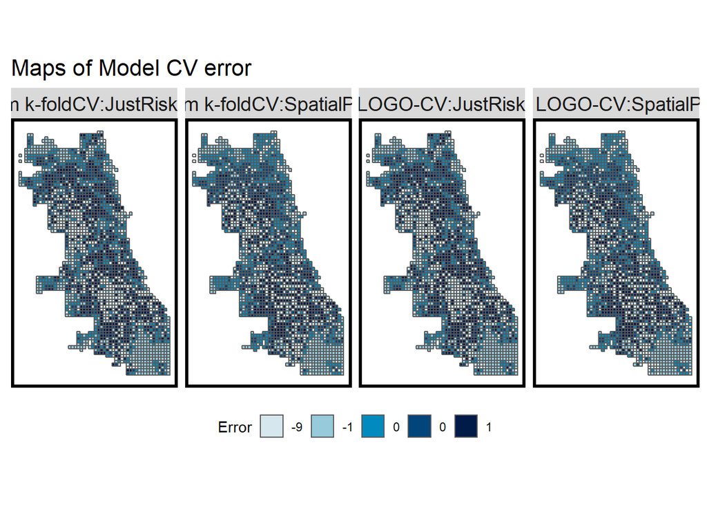

### 9.A table of raw errors by race context for a random k-fold vs. spatial cross validation regression

The model on average, under-predicts in Majority_Non_White neighborhoods and over-predicts in Majority_White neighborhoods.

Mean Error by neighborhood racial context

| Regression | Majority_Non_White | Majority_White |
| --- | --- | --- |
| Random k-foldCV:JustRiskFactors | -0.3868085 | 0.4241534 |
| Random k-foldCV:SpatialProcess | -0.1467751 | 0.1620336 |
| Spatial LOGO-CV:JustRiskFactors | -0.4406241 | 0.4337530 |
| Spatial LOGO-CV:SpatialProcess | -0.1721860 | 0.1661009 |

### 10.The map comparing kernel density to risk predictions for the next year’s crime

I created maps of crime occurrence for 2019 that I predicted through 2018 data, and when compared to the actual crime maps, you can see that they highly matches each other in spatial distribution.

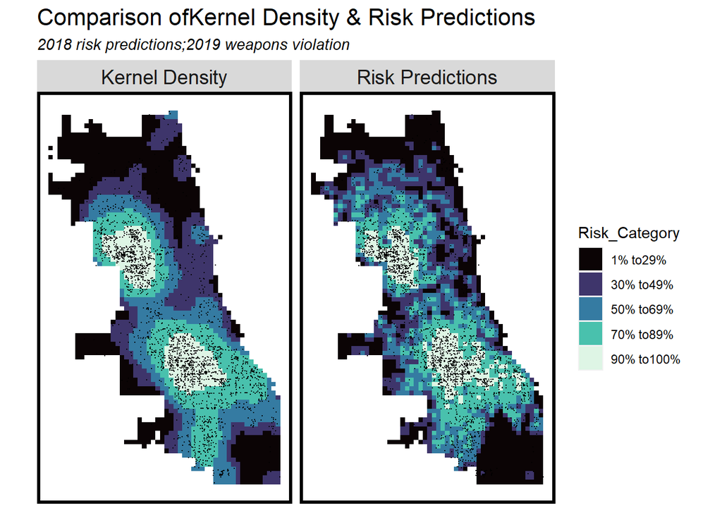

### 11.The bar plot making this comparison

Finally, comparing the predicted data with the actual data, it also shows that they are very close. This proves my model is successful.

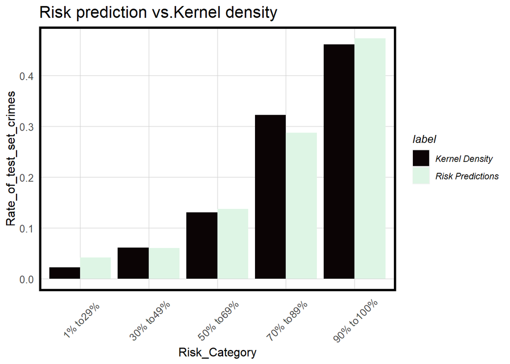

## Conclusion

In general, I highly recommend my model to predict urban crimes, the results of prediction can be used to allocate police response across space.

First, by comparing the predictions with the actual results, we know that it is highly accurate and can accurately predict areas with a higher risk of crime occurrence. The second point is that it can provide strong evidence to assist relevant departments in deploying urban resources and carrying out relevant policies (It can be part of the cost-benefit analysis). If our model provides sufficient evidence that an area needs stronger policing and more social resources, then the area will be more likely to receive government-backed investment and is most likely to receive positive feedback from the investment. Finally, the model is so valuable in its application that it can be used to predict not only crime but also other dispersed events such as store deployments. Therefore, I recommend my model.